# Exponential Distribution

# Introduction

This entire paragraph was taken over from the Introduction to Statistical Thought (written by Michael Lavine; published on June 24, 2010).

It is often necessary to model a continuous random variable X whose density decreases away from 0. Some examples are

- *Customer service* time on hold at a help line
- *Neurobiology* time until the next neuron fires
- *Seismology* time until the next earthquake
- *Medicine* remaining years of life for a cancer patient
- *Ecology* dispersal distance of a seed

In these examples it is expected that most calls, times or distances will be short and a few will be long. So the density should be large near *x = 0* and decreasing as *x* increases.

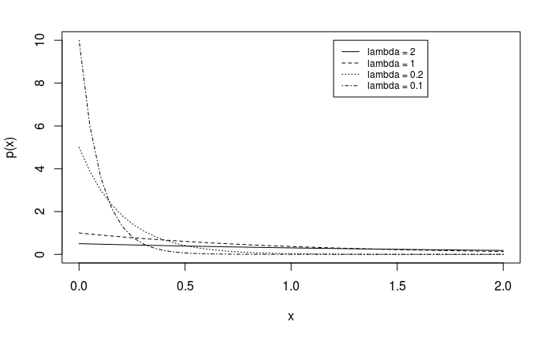

```r
x <- seq ( 0, 2, length=40 ) # 40 values from 0 to 2
lam <- c ( 2, 1, .2, .1 ) # 4 different values of lambda
y <- matrix ( NA, 40, 4 ) # y values for plotting
for ( i in 1:4 )
  y[,i] <- dexp ( x, 1/lam[i] ) # exponential pdf
matplot ( x, y, type="l", xlab="x", ylab="p(x)", col=1 )
legend ( 1.2, 10, paste ( "lambda =", lam ), lty=1:4, cex=.75 )
```

# Generating Exponential Observations

The function which generates exponential observation in R is called *rexp*.

```r
draws <- rexp(400, .1)
mean(draws)
```

```
[1] 8.976586
```

```r
length(draws)
```

```
[1] 400
```

# Probability Density

There is a special function in R which calculates the probability density - it is called *dexp*:

```r
dexp(45, .1)
```

```
[1] 0.0011109
```

# Cumulative Density

There is a special function in R which calculates the cumulative density - it is called *pexp*:

```r
pexp(45, .1)
```

```
[1] 0.988891
```

# Quantiles

Quantile works as an inverse of the cumulative density function, as illustrated below:

```r
qexp(pexp(45, .1), .1)
```

```
[1] 45
```

Visit [Basic Probability Distributions in R](https://rpubs.com/ggraham412/100906) for more information.

# Quantile-Quantile Plots

As described in the [Q-Q Plot Tutorial](https://intellinexus.wordpress.com/2010/11/29/creating-a-q-q-plot/), The quantile-quantile (q-q) plot is a graphical technique for determining if two data sets come from populations with a common distribution.

The following code compares observations stored in *x.sample* with those in *y.sample*:

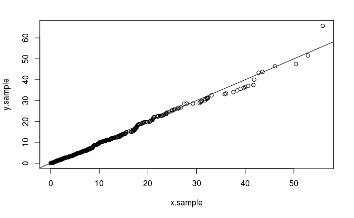

```r
library(tidyverse)
x.sample <- rexp(400, .1)
y.sample <- rexp(400, .1)
qqplot(x.sample, y.sample)
abline(0,1)
```

The same test using *ggplot2*:

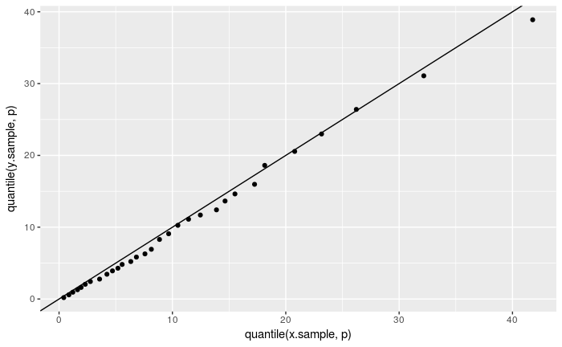

```r
nq <- 31
p <- (1 : nq) / nq - 0.5 / nq
ggplot() + geom_point(aes(x = quantile(x.sample, p), y = quantile(y.sample, p))) +
  geom_abline(intercept = 0, slope = 1)
```

Do the following to compare the *x.sample* with a Exponential distribution Exp(0.1):

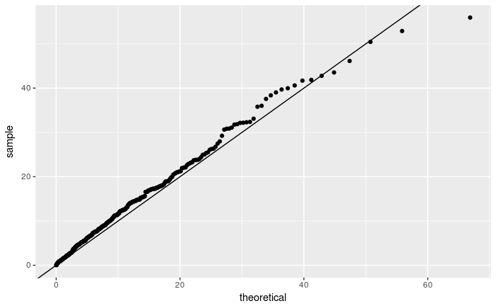

```r
xdf <-data.frame(x = x.sample)
ggplot(xdf, aes(sample = x)) +
  stat_qq(distribution = stats::qexp, dparams = list(rate=.1)) +
  geom_abline(intercept = 0, slope = 1)
```

# Further Reading

- [A quantile-quantile plot](http://ggplot2.tidyverse.org/reference/geom_qq.html)
- [QQ Plots and PP Plots](http://homepage.divms.uiowa.edu/~luke/classes/STAT4580/qqpp.html)
- [Q-Q Plot Tutorial](https://intellinexus.wordpress.com/2010/11/29/creating-a-q-q-plot/)